# Neuroprediction of future rearrest: A re-analysis

This notebook outlines the re-analysis of the criminal prediction data from Aharoni et al. (2013, PNAS). The original code was developed by Russ Poldrack and Jeanette Mumford, and presented at http://www.russpoldrack.org/2013/04/how-well-can-we-predict-future-criminal.html. This notebook is meant to accompany the manuscript titled “Predicting violent behavior: What can neuroscience add?” by R.Poldrack et al.

In these analyses we focus on nonviolent crimes only, excluding parole violations, as nonviolent crime was the subset that was best predicted in the followup study, and there are relatively few rearrests for violent offenses in the dataset.

First we load the data that were downloaded from the PNAS site and converted to text.

```r
alldata=read.table('aharoni_data_fixed.txt',header=TRUE, na.strings=".")
# use the same time cutoff that Aharoni used in their plots
time_cutoff=max(alldata$MinMonthsNonVio[alldata$NonVioChargeSinceScanExclPVs==1])
```

Compute the overall survival curve, and plot the Kaplan-Meier curve.

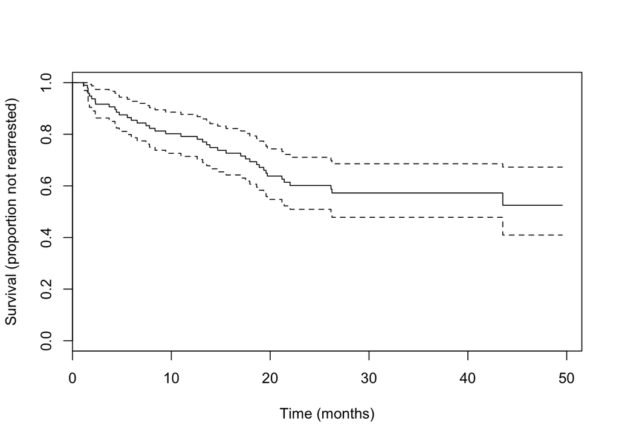

```r
s=survival::Surv(time=alldata$MinMonthsNonVio,event=alldata$NonVioChargeSinceScanExclPVs,type='right')
km=survfit(s~1)
plot(km,xlab='Time (months)',ylab='Survival (proportion not rearrested)')
```

```r
models_nonvio=list("Age"=coxph(Surv(MinMonthsNonVio,   NonVioChargeSinceScanExclPVs)~releaseAge_centered,
                       data=alldata, y=TRUE),
            "dACC"=coxph(Surv(MinMonthsNonVio, NonVioChargeSinceScanExclPVs)~dACC_centered,
                       data=alldata, y=TRUE),
            "Age.dACC"=coxph(Surv(MinMonthsNonVio, NonVioChargeSinceScanExclPVs)~releaseAge_centered+ dACC_centered, data=alldata, y=TRUE))
```

Perform cross-validation and compute prediction error for nonviolent crimes.

```r
force_new=FALSE  # set to true to force rerunning the models

if (!file.exists('pred_err_nonviolent.Rdata') | force_new){

  nrep=1000   # number of crossvalidation runs to average

  pred_err=pec(models_nonvio,formula=Surv(MinMonthsNonVio, NonVioChargeSinceScanExclPVs)~1,
                       data=alldata,
                        splitMethod="cv10", B=nrep,
                        verbose=FALSE,
                        keep.index=TRUE,
                        keep.matrix=TRUE)
  save(pred_err,file='pred_err_nonviolent.Rdata')
} else {
  print('using saved data file')
  load('pred_err_nonviolent.Rdata')
}
```

```
## [1] "using saved data file"
```

```r
print (pred_err)
```

```
##
## Prediction error curves
##
## Prediction models:
##
## Reference       Age      dACC  Age.dACC
## Reference       Age      dACC  Age.dACC
##
## Right-censored response of a survival model
##
## No.Observations: 96
##
## Pattern:
##                 Freq
##  event          40
##  right.censored 56
##
## IPCW: marginal model
##
## Method for estimating the prediction error:
##
##  10-fold cross-validation
##
## Repeated:  1000 times
##
## Cumulative prediction error, aka Integrated Brier score  (IBS)
##  aka Cumulative rank probability score
##
## Range of integration: 0 and time=48 :
##
##
## Integrated Brier score (crps):
##
##      IBS[0;time=48)
## [1,]          0.207
## [2,]          0.202
## [3,]          0.199
## [4,]          0.189
```

```r
cverr=crps(pred_err,times=48.8)[,'crossvalErr']
print(sprintf('Improvement for Age+dACC over Age (nonviolent crimes): %0.3f',(cverr['Age']-cverr['Age.dACC'])/cverr['Age']))
```

```
## [1] "Improvement for Age+dACC over Age (nonviolent crimes): 0.070"
```

Save crossvalidated prediction error across all of the runs for the baseline (Age) and baseline + dACC models. (We will plot it in python using plot_prederr.py)

```r
# first need to collapse the error into individual variables
nrep=length(pred_err$CrossValErrMat)
npts=length(pred_err$CrossValErrMat[[1]]$Reference)-1 # remove last point
baseline_cverr=matrix(NA,nrep,npts)
dacc_cverr=matrix(NA,nrep,npts)
for (r in 1:nrep){
  baseline_cverr[r,]=pred_err$CrossValErrMat[[r]]$Age[1:npts]
  dacc_cverr[r,]=pred_err$CrossValErrMat[[r]]$Age.dACC[1:npts]
}
mean_baseline_err=apply(baseline_cverr,2,mean)
mean_dacc_err=apply(dacc_cverr,2,mean)
goodtps=which(pred_err$time<=time_cutoff)
df=data.frame(pred_err$time[goodtps],mean_baseline_err[goodtps],mean_dacc_err[goodtps])
names(df)=c('time','baseline','dacc')
write.table(df,file='cverr_data.txt')
```

Make figures using Python.

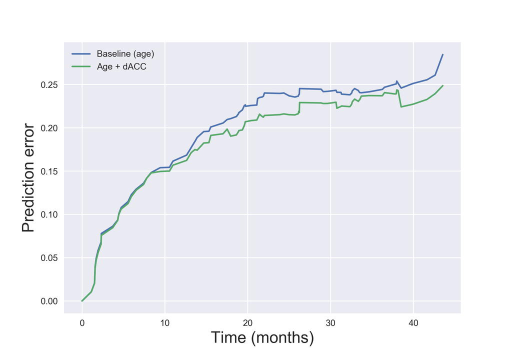

```r
system('bash runpy.sh')
library(knitr)
knitr::include_graphics('prediction_error.png')
```

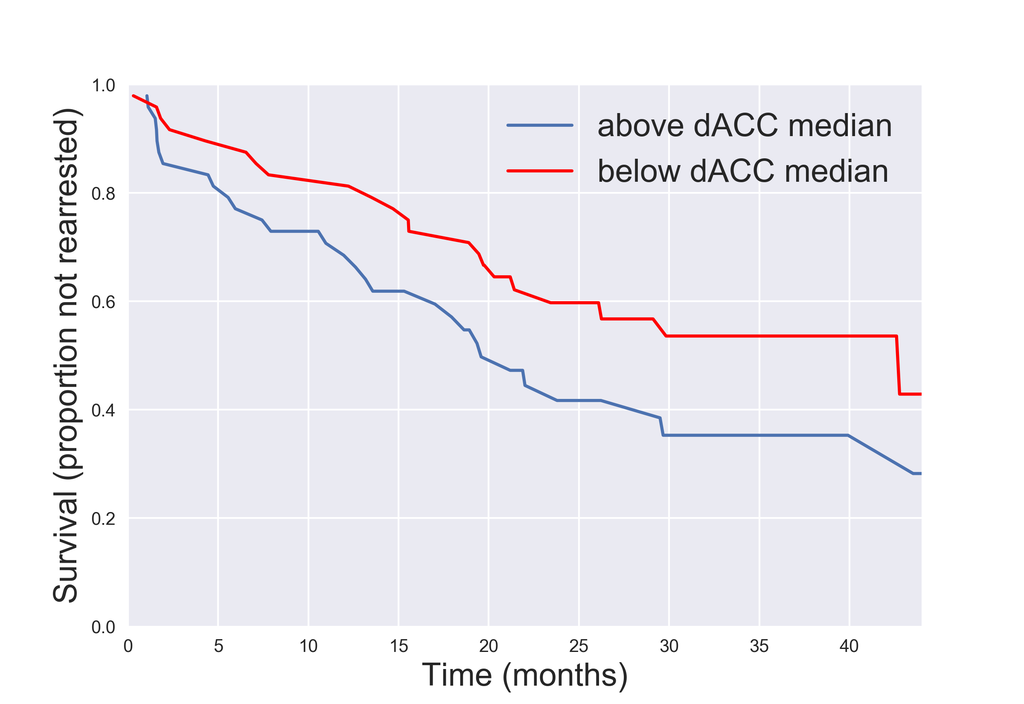

```r
knitr::include_graphics('survival_by_dACC.png')
```

Run same analysis using .632+ bootstrap rather than crossvalidation.

```r
force_new=FALSE  # set to true to force rerunning the models

if (!file.exists('pred_err_nonviolent_boot.Rdata') | force_new){

  nrep=1000   # number of crossvalidation runs to average

  pred_err_boot=pec(models_nonvio,formula=Surv(MinMonthsNonVio, NonVioChargeSinceScanExclPVs)~1,
                       data=alldata,
                        splitMethod="Boot632plus", B=nrep,
                        verbose=FALSE,
                        keep.index=TRUE,
                        keep.matrix=TRUE)
  save(pred_err_boot,file='pred_err_nonviolent_boot.Rdata')
} else {
  print('using saved data file')
  load('pred_err_nonviolent_boot.Rdata')
}
```

```
## [1] "using saved data file"
```

```r
print (pred_err_boot)
```

```
##
## Prediction error curves
##
## Prediction models:
##
## Reference       Age      dACC  Age.dACC
## Reference       Age      dACC  Age.dACC
##
## Right-censored response of a survival model
##
## No.Observations: 96
##
## Pattern:
##                 Freq
##  event          40
##  right.censored 56
##
## IPCW: marginal model
##
## Method for estimating the prediction error:
##
## Bootstrap cross-validation
##
## Type: resampling
## Bootstrap sample size:  96
## No. bootstrap samples:  1000
## Sample size:  96
##
## Cumulative prediction error, aka Integrated Brier score  (IBS)
##  aka Cumulative rank probability score
##
## Range of integration: 0 and time=45.5 :
##
##
## Integrated Brier score (crps):
##
##           IBS[0;time=45.5)
## Reference            0.199
## Age                  0.201
## dACC                 0.198
## Age.dACC             0.188
```

```r
booterr=crps(pred_err_boot,times=46.6)[,'Boot632plusErr']
print(sprintf('Improvement for Age+dACC over Age (nonviolent crimes - boot632+): %0.3f',(booterr['Age']-booterr['Age.dACC'])/booterr['Age']))
```

[output not shown]

Run analysis using AUC rather than Brier index, as suggested by Peter Imrey.

```r
library(survAUC)

get_auc_fold = function(alldata, trainpts,testpts){
  traindata=alldata[trainpts,]
  testdata=alldata[testpts,]
  Surv.rsp <- Surv(traindata$MinMonthsNonVio, traindata$NonVioChargeSinceScanExclPVs)
  Surv.rsp.new <- Surv(testdata$MinMonthsNonVio, testdata$NonVioChargeSinceScanExclPVs)

  train.fit.Age=coxph(Surv(MinMonthsNonVio,   NonVioChargeSinceScanExclPVs)~releaseAge_centered,
                         data=traindata, y=TRUE)

  lpnew.Age <- predict(train.fit.Age, newdata=testdata)

  train.fit.Age_dACC=coxph(Surv(MinMonthsNonVio,   NonVioChargeSinceScanExclPVs)~releaseAge_centered + dACC_centered,
                         data=traindata, y=TRUE)

  lpnew.Age_dACC <- predict(train.fit.Age_dACC, newdata=testdata)


  times=seq(1,44)
  AUC_Uno_Age <- AUC.uno(Surv.rsp, Surv.rsp.new, lpnew.Age, times)
  AUC_Uno_Age_dACC <- AUC.uno(Surv.rsp, Surv.rsp.new, lpnew.Age_dACC, times)

  return(c(AUC_Uno_Age$iauc,AUC_Uno_Age_dACC$iauc))
}

force_new=FALSE  # set to true to force rerunning the models

if (!file.exists('AUC_results.Rdata') | force_new){

  nruns=1000
  nfolds=10
  results=c()
  for (r in 1:nruns) {
    folds=createFolds(alldata$MinMonthsDV_noPVs,nfolds,list=FALSE)
    for (f in 1:nfolds){
      trainIndexes =  which(folds!=f,arr.ind=TRUE)
      testIndexes <- which(folds==f,arr.ind=TRUE)
      results=rbind(results,get_auc_fold(alldata,trainIndexes,testIndexes))

    }
  }
  save(results,file='AUC_results.Rdata')

} else {
  print('using saved AUC data file')
  load('AUC_results.Rdata')
}
```

```
## [1] "using saved AUC data file"
```

```r
mean_auc=apply(results,2,mean)
print(sprintf('AUC - age: %f',mean_auc[1]))
```

```
## [1] "AUC - age: 0.630663"
```

```r
print(sprintf('AUC - age + dACC: %f',mean_auc[2]))
```

```
## [1] "AUC - age + dACC: 0.687789"
```

```r
print('AUC ratio for age+dACC vs. age alone')
```

```
## [1] "AUC ratio for age+dACC vs. age alone"
```

```r
print((mean_auc[2]-mean_auc[1])/mean_auc[1])
```

```
## [1] 0.09058156
```